# Άσκηση 3 - Ανάλυση Πωλήσεων Μπίρας

# 6 Εποχικοί Δείκτες (Ερώτημα 1 - Βήμα γ)

```r
# Αποσύνθεση με πολλαπλασιαστικό μοντέλο
decomp <- decompose(ts_sales, type = "multiplicative")

# Ακατέργαστοι μέσοι ανά εποχή
# Μέσος όρος όλων των Y/CMA για κάθε εποχή
# Έτσι ο τυχαίος παράγοντας I "ακυρώνεται"
raw_indices <- tapply(as.numeric(ratios), cycle(ts_sales), mean, na.rm = TRUE)
cat("=== Ακατέργαστοι Μέσοι Όροι ===\n")
```

```
## === Ακατέργαστοι Μέσοι Όροι ===
```

```r
print(round(raw_indices, 4))
```

```
##      1      2      3      4
## 0.4065 0.6813 1.7116 1.1409
```

```r
cat("Άθροισμα:", round(sum(raw_indices), 4), "\n")
```

```
## Άθροισμα: 3.9404
```

```r
# Κανονικοποίηση: άθροισμα = 4 (πλήθος εποχών)
normalization_factor <- 4 / sum(raw_indices)
final_indices <- raw_indices * normalization_factor

cat("\n=== Τελικοί Εποχιακοί Δείκτες (Κανονικοποιημένοι) ===\n")
```

```
##
## === Τελικοί Εποχιακοί Δείκτες (Κανονικοποιημένοι) ===
```

```r
print(round(final_indices, 4))
```

```
##      1      2      3      4
## 0.4126 0.6916 1.7375 1.1582
```

```r
cat("Νέο Άθροισμα:", round(sum(final_indices), 4), "\n")
```

```
## Νέο Άθροισμα: 4
```

```r
# Επαλήθευση με decompose
seasonal_indices <- decomp$seasonal[1:4]
names(seasonal_indices) <- c("Χειμώνας", "Άνοιξη", "Καλοκαίρι", "Φθινόπωρο")
cat("\n=== Επαλήθευση μέσω decompose ===\n")
```

```
##
## === Επαλήθευση μέσω decompose ===
```

```r
print(round(seasonal_indices, 4))
```

```
##  Χειμώνας    Άνοιξη Καλοκαίρι Φθινόπωρο
##    0.4126    0.6916    1.7375    1.1582
```

**Ερμηνεία εποχικών δεικτών:**

- Χειμώνας: 0.41 — πωλήσεις στο 41% του μέσου (-59%)
- Άνοιξη: 0.69 — πωλήσεις στο 69% του μέσου (-31%)
- Καλοκαίρι: 1.74 — πωλήσεις στο 174% του μέσου (+74%)
- Φθινόπωρο: 1.16 — πωλήσεις στο 116% του μέσου (+16%)

# 7 Εξάλειψη Εποχικότητας (Ερώτημα 1)

```r
# Αποεποχικοποίηση: Y / S
# Αφαιρούμε την εποχική επίδραση
# Αποτέλεσμα: σειρά που περιέχει μόνο Τάση + Κύκλος + Τυχαίο
deseasonalized_sales <- ts_sales / decomp$seasonal

cat("=== Αποεποχικοποιημένα Δεδομένα (Y/S) ===\n")
```

```
## === Αποεποχικοποιημένα Δεδομένα (Y/S) ===
```

```r
print(round(deseasonalized_sales, 2))
```

```
##      Qtr1 Qtr2 Qtr3 Qtr4
## 2016 2.42 4.34 3.45 3.45
## 2017 4.85 2.89 4.03 4.32
## 2018 4.85 5.78 4.60 4.32
## 2019 2.42 4.34 4.60 5.18
```

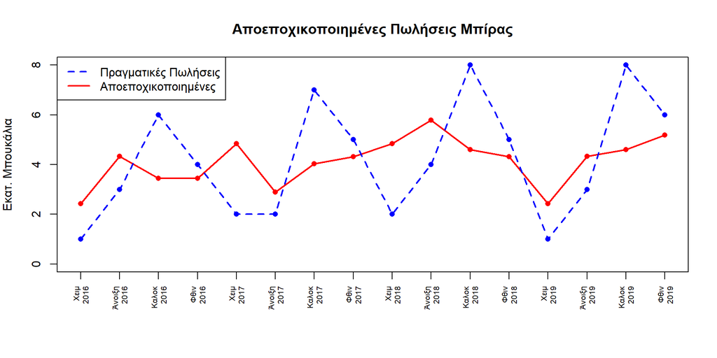

```r
time_labels <- c("Χειμ\n2016","Άνοιξη\n2016","Καλοκ\n2016","Φθιν\n2016",
                 "Χειμ\n2017","Άνοιξη\n2017","Καλοκ\n2017","Φθιν\n2017",
                 "Χειμ\n2018","Άνοιξη\n2018","Καλοκ\n2018","Φθιν\n2018",
                 "Χειμ\n2019","Άνοιξη\n2019","Καλοκ\n2019","Φθιν\n2019")

par(mar = c(6, 4, 4, 2))
plot(as.numeric(deseasonalized_sales), type = "o",
     col = "red", lwd = 2, pch = 16,
     main = "Αποεποχικοποιημένες Πωλήσεις Μπίρας",
     ylab = "Εκατ. Μπουκάλια", xlab = "",
     xaxt = "n", ylim = c(0, 8))
lines(as.numeric(ts_sales), type = "o",
      col = "blue", lwd = 2, pch = 16, lty = 2)
axis(1, at = 1:16, labels = time_labels, cex.axis = 0.65, las = 2)
legend("topleft",
       legend = c("Πραγματικές Πωλήσεις", "Αποεποχικοποιημένες"),
       col = c("blue", "red"), lty = c(2, 1), lwd = 2)
```

**Παρατήρηση:** Η κόκκινη γραμμή είναι πολύ πιο ομαλή — οι διακυμάνσεις χειμώνα-καλοκαιριού έχουν αφαιρεθεί. Αποκαλύπτεται η υποκείμενη τάση.

# 8 Γραμμή Τάσης (Ερώτημα 2)

```r
# Γραμμική παλινδρόμηση πάνω στα αποεποχικοποιημένα δεδομένα
# Εξίσωση: y_hat = a + b*t
# a: επίπεδο εκκίνησης, b: μέση μεταβολή ανά τρίμηνο
t <- 1:length(sales)
trend_model <- lm(deseasonalized_sales ~ t)

cat("=== Εξίσωση Γραμμής Τάσης ===\n")
```

```
## === Εξίσωση Γραμμής Τάσης ===
```

```r
summary(trend_model)
```

```
##
## Call:
## lm(formula = deseasonalized_sales ~ t)
##
## Residuals:
##      Min       1Q   Median       3Q      Max
## -2.06225 -0.24572 -0.00476  0.50858  1.54449
##
## Coefficients:
##             Estimate Std. Error t value Pr(>|t|)
## (Intercept)  3.41652    0.47429   7.203 4.54e-06 ***
## t            0.08224    0.04905   1.677    0.116
## ---
## Signif. codes:  0 '***' 0.001 '**' 0.01 '*' 0.05 '.' 0.1 ' ' 1
##
## Residual standard error: 0.9044 on 14 degrees of freedom
## Multiple R-squared:  0.1672, Adjusted R-squared:  0.1078
## F-statistic: 2.812 on 1 and 14 DF,  p-value: 0.1158
```

**Αποτελέσματα:**

- a = 3.417: εκτιμώμενες πωλήσεις στην αρχή της περιόδου
- b = 0.082: αύξηση 0.082 εκατ. μπουκάλια ανά τρίμηνο
- p-value (b) = 0.116 > 0.05: ασθενής τάση, μη στατιστικά σημαντική
- R² = 0.167: η τάση εξηγεί μόνο το 16.7% της μεταβλητότητας

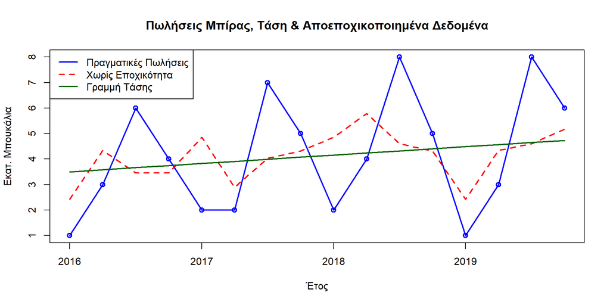

```r
trend_line <- fitted(trend_model)

plot(ts_sales, type = "o", col = "blue", lwd = 2,
     main = "Πωλήσεις Μπίρας, Τάση & Αποεποχικοποιημένα Δεδομένα",
     ylab = "Εκατ. Μπουκάλια", xlab = "Έτος")
lines(deseasonalized_sales, col = "red", lwd = 2, lty = 2)
lines(ts(trend_line, start = c(2016, 1), frequency = 4),
      col = "darkgreen", lwd = 2)
legend("topleft",
       legend = c("Πραγματικές Πωλήσεις", "Χωρίς Εποχικότητα", "Γραμμή Τάσης"),
       col = c("blue", "red", "darkgreen"), lty = c(1, 2, 1), lwd = 2)
```

# 9 Κυκλικά Κατάλοιπα (Ερώτημα 3)

```r
# Σχετικά Κυκλικά Κατάλοιπα = (Y/S - T_hat) / T_hat x 100
# Θετικό: φάση άνθησης (πωλήσεις πάνω από τάση)
# Αρνητικό: φάση ύφεσης (πωλήσεις κάτω από τάση)
cyclical_residuals <- (deseasonalized_sales - trend_line) / trend_line

# Πίνακας αποτελεσμάτων
cyclical_table <- data.frame(
  Ετος   = rep(2016:2019, each = 4),
  Εποχη  = rep(c("Χειμώνας", "Άνοιξη", "Καλοκαίρι", "Φθινόπωρο"), 4),
  Κυκλικο = paste0(round(as.numeric(cyclical_residuals) * 100, 2), "%")
)
print(cyclical_table)
```

```
##    Ετος     Εποχη Κυκλικο
## 1  2016  Χειμώνας -30.73%
## 2  2016    Άνοιξη  21.13%
## 3  2016 Καλοκαίρι  -5.74%
## 4  2016 Φθινόπωρο  -7.79%
## 5  2017  Χειμώνας  26.63%
## 6  2017    Άνοιξη -26.04%
## 7  2017 Καλοκαίρι   0.91%
## 8  2017 Φθινόπωρο   5.95%
## 9  2018  Χειμώνας   16.6%
## 10 2018    Άνοιξη  36.44%
## 11 2018 Καλοκαίρι   6.55%
## 12 2018 Φθινόπωρο  -1.96%
## 13 2019  Χειμώνας -45.97%
## 14 2019    Άνοιξη  -5.04%
## 15 2019 Καλοκαίρι  -0.99%
## 16 2019 Φθινόπωρο   9.47%
```

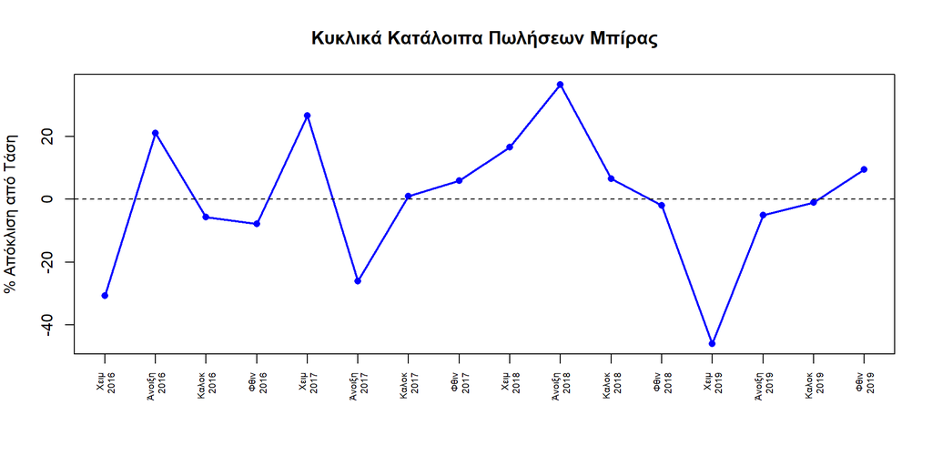

```r
par(mar = c(6, 4, 4, 2))
plot(as.numeric(cyclical_residuals) * 100, type = "o",
     col = "blue", lwd = 2, pch = 16,
     main = "Κυκλικά Κατάλοιπα Πωλήσεων Μπίρας",
     ylab = "% Απόκλιση από Τάση", xlab = "",
     xaxt = "n")
abline(h = 0, col = "black", lty = 2)
axis(1, at = 1:16, labels = time_labels, cex.axis = 0.6, las = 2)
```

**Παρατηρήσεις:**

- Μέγιστη θετική απόκλιση: Άνοιξη 2018 (+36.4%) — φάση άνθησης
- Μέγιστη αρνητική απόκλιση: Χειμώνας 2019 (-46.0%) — έντονη φάση ύφεσης
- Οι αποκλίσεις δεν οφείλονται στην εποχικότητα ή την τάση, αλλά σε εξωγενείς οικονομικούς παράγοντες

# 10 Συμπεράσματα

- Τα δεδομένα παρουσιάζουν **έντονη εποχικότητα** — το καλοκαίρι κινεί εντελώς την αγορά (+74%)
- Η γραμμή τάσης δείχνει ήπια ανοδική πορεία (b = 0.082) που δεν είναι στατιστικά σημαντική (p = 0.116)
- Η ανάπτυξη της επιχείρησης υπάρχει αλλά είναι αργή και αβέβαιη
- Η απότομη ύφεση του Χειμώνα 2019 (-46%) υποδηλώνει εξωγενή οικονομικό κλονισμό που χρήζει διερεύνησης